# Absorbances Third Project

ContextBase, http://contextbase.github.io

John Akwei, ECMp ERMp Data Scientist

January 29, 2016

# Synopsis

This document is the third analysis of absorbance data involving E.Coli and S.Aureus. Via Data Science analysis, (using the R programming language), the document author intends to build an understanding, numerically and statistically, of the difference between the samples, with p-values, t-tests, etc.

The datasets examined are:  
Dataset 3 - fib_vs_ABS_ecoli_.xlsx  
Dataset 4 - fib_vs_ABS_s_aureus2.xlsx  
Dataset 5 - disc_ecoli.xlsx  
Dataset 6 - disc_SA.xlsx  
Dataset 7 - fill_vs_ecoli.xlsx  
Dataset 8 - fil_vs_S_aureus2.xlsx

The data is re-formatted, in order that each row is a separate record, and the first row contains the variable names.

The free, open source application RStudio, (version 0.98.1103), was used for the analysis. The version of the R programming language used was, R version 3.2.0 (2015-04-16). The PC operating system is Windows 8.1.

#### Processing Requirements

```r
setwd("C:/Users/johnakwei/Dropbox/Programming/Morphotypes")
if (!require("ggplot2")) {install.packages("ggplot2"); require("ggplot2")}
if (!require("xlsx")) {install.packages("xlsx"); require("xlsx")}
```

# Dataset 3 - Data Input

```r
fib_vs_ABS_ecoli_ <- read.xlsx("fib_vs_ABS_ecoli_.xlsx", 1)
```

# Dataset 3 - Graphs, Linear Regression, Correlation, and T-Tests

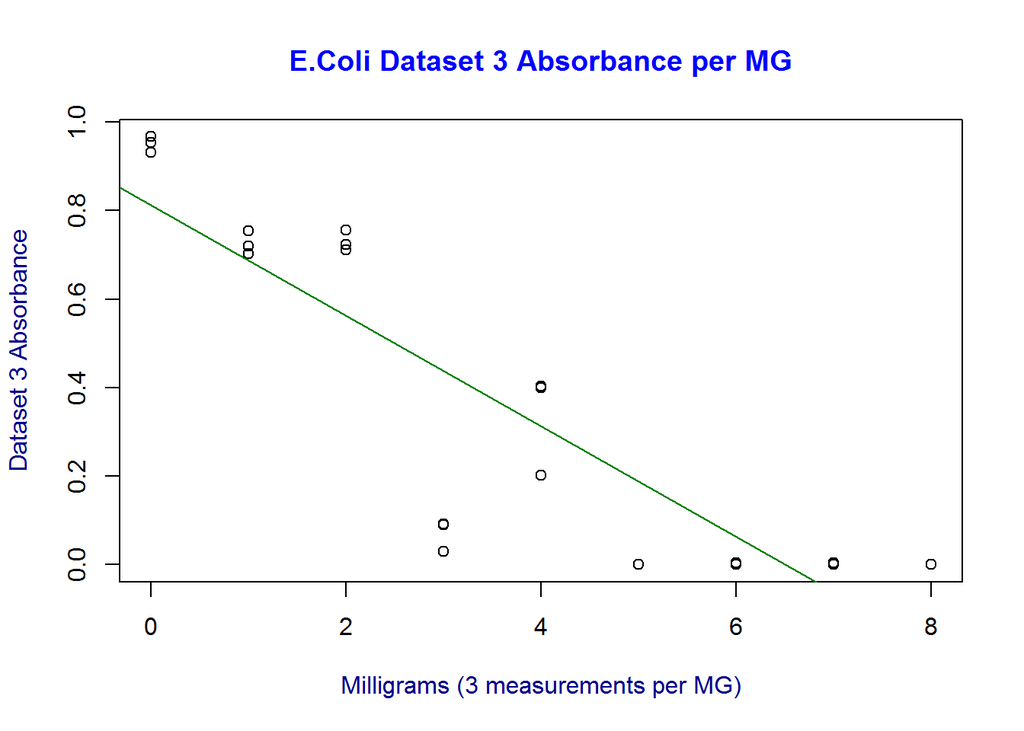

```r
plot(fib.vs.ABS.e.Coli$fib_vs_ABS_e_coli, fib.vs.ABS.e.Coli$Sample_1,
     main="E.Coli Dataset 3 Absorbance per MG",
     col.main="blue", xlab="Milligrams (3 measurements per MG)",
     ylab="Dataset 3 Absorbance",
     col.lab="darkblue")
abline(lm(fib.vs.ABS.e.Coli$Sample_1~fib.vs.ABS.e.Coli$fib_vs_ABS_e_coli),
       col="#008000")
```

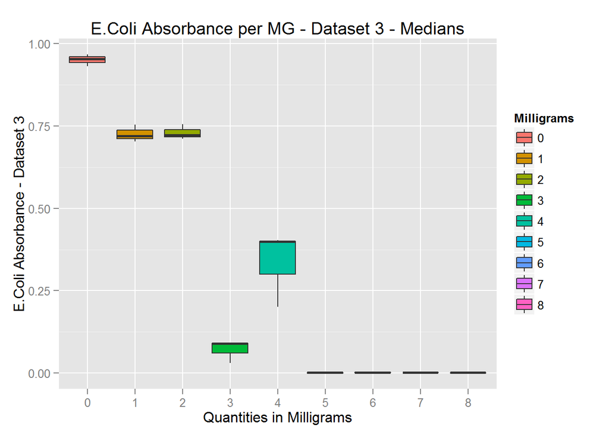

```r
ggplot(fib.vs.ABS.e.Coli,
       aes(x=as.factor(fib.vs.ABS.e.Coli$fib_vs_ABS_e_coli),
           y=fib.vs.ABS.e.Coli$Sample_1)) +
geom_boxplot(aes(fill=as.factor(fib.vs.ABS.e.Coli$fib_vs_ABS_e_coli))) +
ggtitle("E.Coli Absorbance per MG - Dataset 3 - Medians") +
xlab("Quantities in Milligrams") + ylab("E.Coli Absorbance - Dataset 3") +
labs(fill="Milligrams")
```

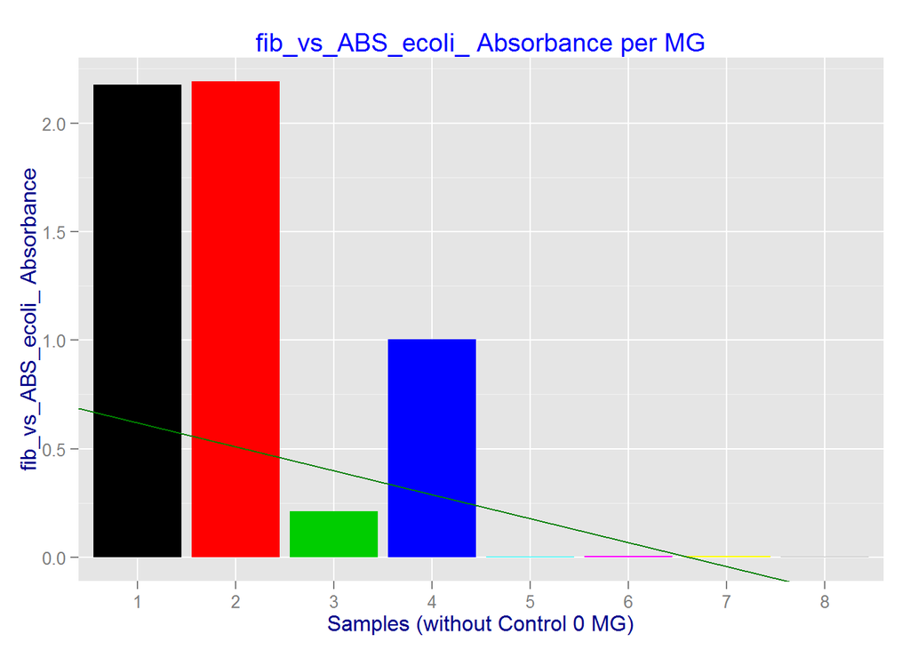

```r
rLine <- coef(lm(fib.vs.ABS.e.Coli$Sample_1[4:27]~
                   fib.vs.ABS.e.Coli$fib_vs_ABS_e_coli[4:27],
                 data=fib.vs.ABS.e.Coli[4:27,]))
layout(matrix(1,1,1))
ggplot(fib.vs.ABS.e.Coli[4:27,],
       aes(x=as.factor(fib.vs.ABS.e.Coli$fib_vs_ABS_e_coli[4:27]),
                              y=fib.vs.ABS.e.Coli$Sample_1[4:27])) +
  geom_bar(aes(), stat="identity",
           fill=as.factor(fib.vs.ABS.e.Coli$fib_vs_ABS_e_coli[4:27])) +
  ggtitle("fib_vs_ABS_ecoli_ Absorbance per MG") +
  xlab("Samples (without Control 0 MG)") +
  ylab("fib_vs_ABS_ecoli_ Absorbance") +
  theme(plot.title=element_text(color="blue")) +
  theme(axis.title=element_text(color="darkblue")) +
  geom_abline(intercept=rLine[1], slope=rLine[2], col="#008000")
```

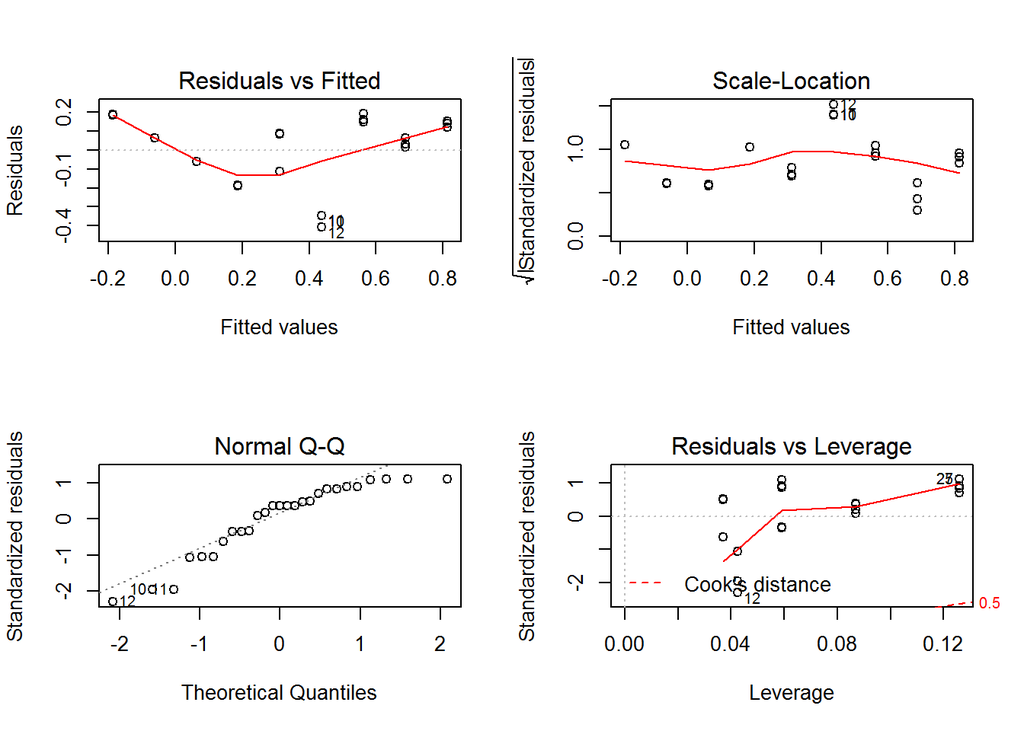

```r
fit <- lm(fib.vs.ABS.e.Coli$Sample_1~
                   fib.vs.ABS.e.Coli$fib_vs_ABS_e_coli)
layout(matrix(c(1,2,3,4),2,2))
plot(fit)
```

### Dataset 3 - Linear Regression Plots

```r
cor.test(as.numeric(fib.vs.ABS.e.Coli$fib_vs_ABS_e_coli),
         fib.vs.ABS.e.Coli$Sample_1, method="spearman")
```

```
##
##  Spearman's rank correlation rho
##
## data:  as.numeric(fib.vs.ABS.e.Coli$fib_vs_ABS_e_coli) and fib.vs.ABS.e.Coli$Sample_1
## S = 6213.3, p-value = 2.497e-10
## alternative hypothesis: true rho is not equal to 0
## sample estimates:
##        rho
## -0.8966206
```

### Dataset 3 - Spearman’s Rank Correlation

The test statistic equals 6213.3, therefore the Dataset 3 fib_vs_ABS_ecoli_ data points demonstrate reliability as predictors. The Spearman’s Rank, or rho, never equals 0, and the Null Hypothesis isn’t supported.

```r
t.test(as.numeric(fib.vs.ABS.e.Coli$fib_vs_ABS_e_coli),
         fib.vs.ABS.e.Coli$Sample_1)
```

```
##
##  Welch Two Sample t-test
##
## data:  as.numeric(fib.vs.ABS.e.Coli$fib_vs_ABS_e_coli) and fib.vs.ABS.e.Coli$Sample_1
## t = 7.2089, df = 27.048, p-value = 9.307e-08
## alternative hypothesis: true difference in means is not equal to 0
## 95 percent confidence interval:
##  2.637677 4.736323
## sample estimates:
## mean of x mean of y
##     4.000     0.313
```

### Dataset 3 - T-Test

The Null Hypothesis is rejected, because the 95% confidence interval has a median above 1.5. The Alternate Hypothesis results are not equal to zero, therefore not supported by the data. The Dataset 3 test results do not conclusively predict the behavior of the response variables accurately.

# Dataset 4 - Data Input

```r
fib_vs_ABS_s_aureus2 <- read.xlsx("fib_vs_ABS_s_aureus2.xlsx", 1)
```

# Dataset 4 - Graphs, Linear Regression, Correlation, and T-Tests

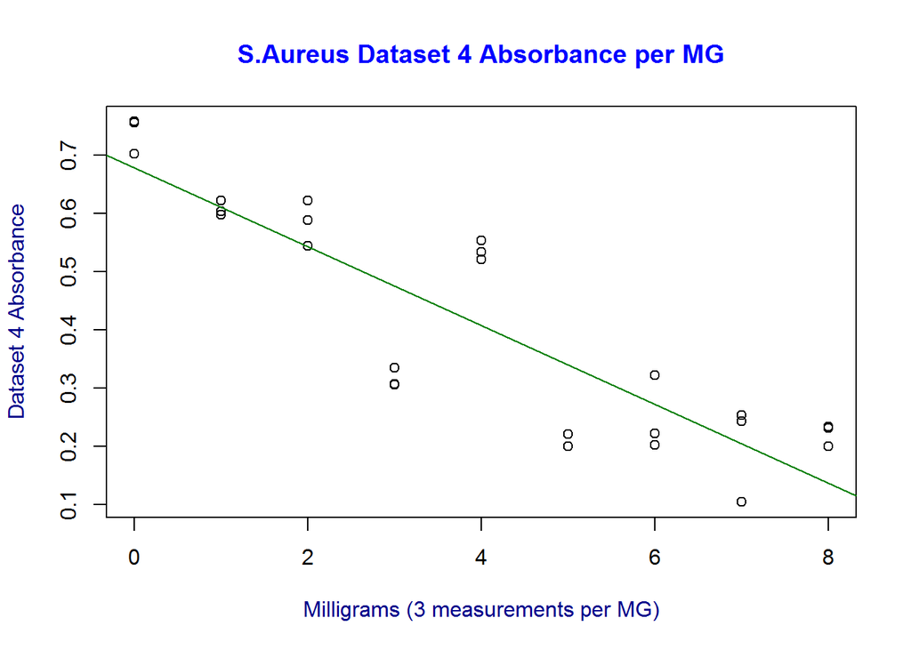

```r
plot(fib_vs_ABS_s_Aureus2$fib_vs_ABS_s_Aureus, fib_vs_ABS_s_Aureus2$Sample_1,
     main="S.Aureus Dataset 4 Absorbance per MG",
     col.main="blue", xlab="Milligrams (3 measurements per MG)",
     ylab="Dataset 4 Absorbance",
     col.lab="darkblue")
abline(lm(fib_vs_ABS_s_Aureus2$Sample_1~
            fib_vs_ABS_s_Aureus2$fib_vs_ABS_s_Aureus),
       col="#008000")
```

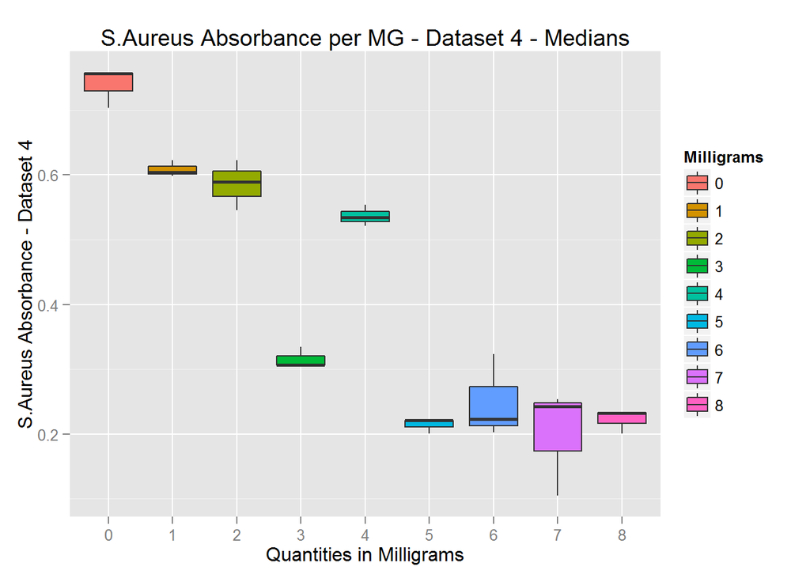

```r
ggplot(fib_vs_ABS_s_Aureus2,
       aes(x=as.factor(fib_vs_ABS_s_Aureus2$fib_vs_ABS_s_Aureus),
           y=fib_vs_ABS_s_Aureus2$Sample_1)) +
geom_boxplot(aes(fill=as.factor(fib_vs_ABS_s_Aureus2$fib_vs_ABS_s_Aureus))) +
ggtitle("S.Aureus Absorbance per MG - Dataset 4 - Medians") +
xlab("Quantities in Milligrams") + ylab("S.Aureus Absorbance - Dataset 4") +
labs(fill="Milligrams")
```

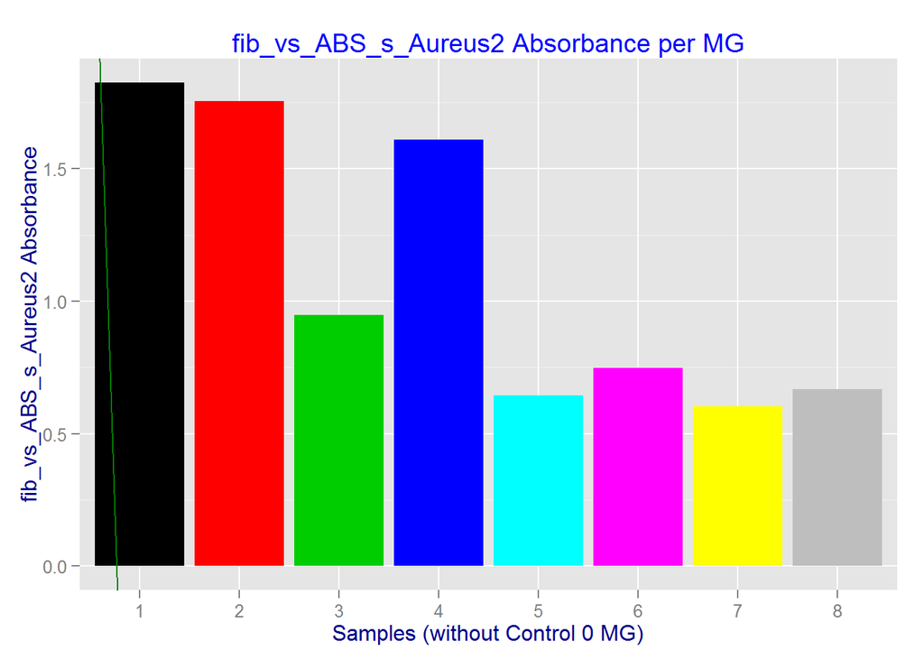

```r
rLine <- coef(lm(fib_vs_ABS_s_Aureus2$fib_vs_ABS_s_Aureus[4:27]~
                   fib_vs_ABS_s_Aureus2$Sample_1[4:27],
                 data=fib_vs_ABS_s_Aureus2[4:27,]))
layout(matrix(1,1,1))
ggplot(fib.vs.ABS.e.Coli[4:27,],
       aes(x=as.factor(fib_vs_ABS_s_Aureus2$fib_vs_ABS_s_Aureus[4:27]),
                              y=fib_vs_ABS_s_Aureus2$Sample_1[4:27])) +
  geom_bar(aes(), stat="identity",
           fill=as.factor(fib_vs_ABS_s_Aureus2$fib_vs_ABS_s_Aureus[4:27])) +
  ggtitle("fib_vs_ABS_s_Aureus2 Absorbance per MG") +
  xlab("Samples (without Control 0 MG)") +
  ylab("fib_vs_ABS_s_Aureus2 Absorbance") +
  theme(plot.title=element_text(color="blue")) +
  theme(axis.title=element_text(color="darkblue")) +
  geom_abline(intercept=rLine[1], slope=rLine[2], col="#008000")
```

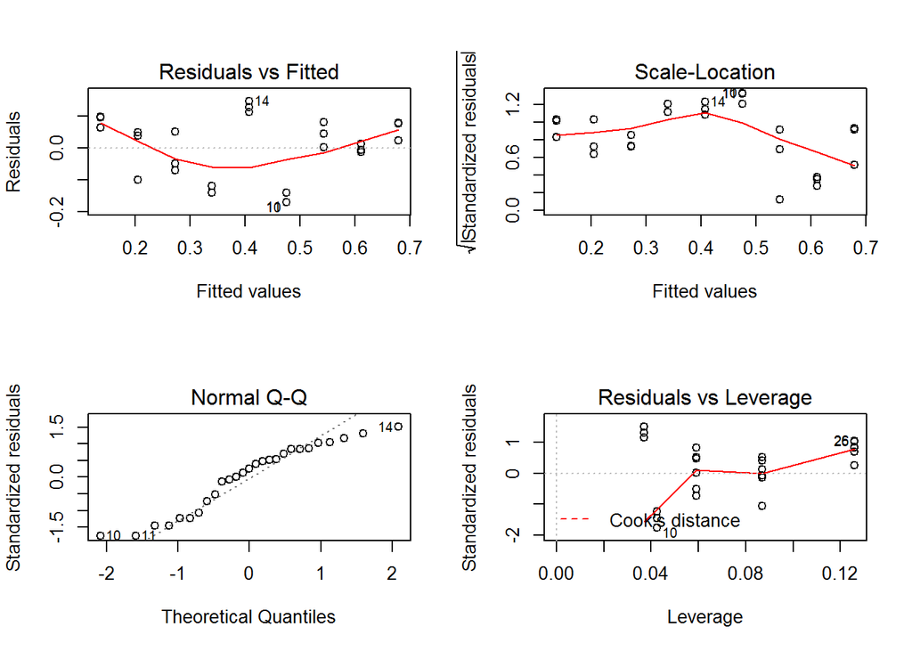

```r
fit <- lm(fib_vs_ABS_s_Aureus2$Sample_1~
                   fib_vs_ABS_s_Aureus2$fib_vs_ABS_s_Aureus)
layout(matrix(c(1,2,3,4),2,2))
plot(fit)
```

### Dataset 4 - Linear Regression Plots

1. Residuals vs. Fitted - the shape of the plot shows a linear relationship in the eight sets of three data points of the fib_vs_ABS_s_Aureus2 data.
2. Normal Q-Q - demonstrates that Linear Regression maintains accuracy, and proves the predictive ability of Dataset 4 - fib_vs_ABS_s_Aureus2.
3. Scale-Location - demonstrates homoscedasticity in Dataset 4, (equal distribution of residuals along the range of predictors).
4. Residuals vs Leverage - the Cook’s distance line is visible. Data points 10 and 26 are influential cases in Dataset 4- fib_vs_ABS_s_Aureus2.

```r
cor.test(as.numeric(fib_vs_ABS_s_Aureus2$fib_vs_ABS_s_Aureus),
         fib_vs_ABS_s_Aureus2$Sample_1, method="spearman")
```

```
##
##  Spearman's rank correlation rho
##
## data:  as.numeric(fib_vs_ABS_s_Aureus2$fib_vs_ABS_s_Aureus) and fib_vs_ABS_s_Aureus2$Sample_1
## S = 6094.8, p-value = 8.669e-09
## alternative hypothesis: true rho is not equal to 0
## sample estimates:
##       rho
## -0.860444
```

### Dataset 4 - Spearman’s Rank Correlation

The test statistic equals 6094.8, therefore Dataset 4- fib_vs_ABS_s_Aureus2 demonstrates reliability in response variables being affected by predictor variables. The Spearman’s Rank, or rho, never equals 0, and the Null Hypothesis isn’t supported.

```r
t.test(as.numeric(fib_vs_ABS_s_Aureus2$fib_vs_ABS_s_Aureus),
         fib_vs_ABS_s_Aureus2$Sample_1)
```

```
##
##  Welch Two Sample t-test
##
## data:  as.numeric(fib_vs_ABS_s_Aureus2$fib_vs_ABS_s_Aureus) and fib_vs_ABS_s_Aureus2$Sample_1
## t = 7.0726, df = 26.309, p-value = 1.537e-07
## alternative hypothesis: true difference in means is not equal to 0
## 95 percent confidence interval:
##  2.548628 4.635320
## sample estimates:
## mean of x mean of y
## 4.0000000 0.4080259
```

### Dataset 4 - T-Test

The 95% confidence interval has a median above 1.5, therefore the Null Hypothesis, (that difference in absorbtion in Dataset 4 - fib_vs_ABS_s_Aureus2 doesn’t exist), is rejected. The Alternate Hypothesis results are not equal to zero, therefore not supported by the data.

# Dataset 5 - Data Input

```r
disc_ecoli <- read.xlsx("disc_ecoli.xlsx", 1)
```

# Dataset 5 - Graphs, Linear Regression, Correlation, and T-Tests

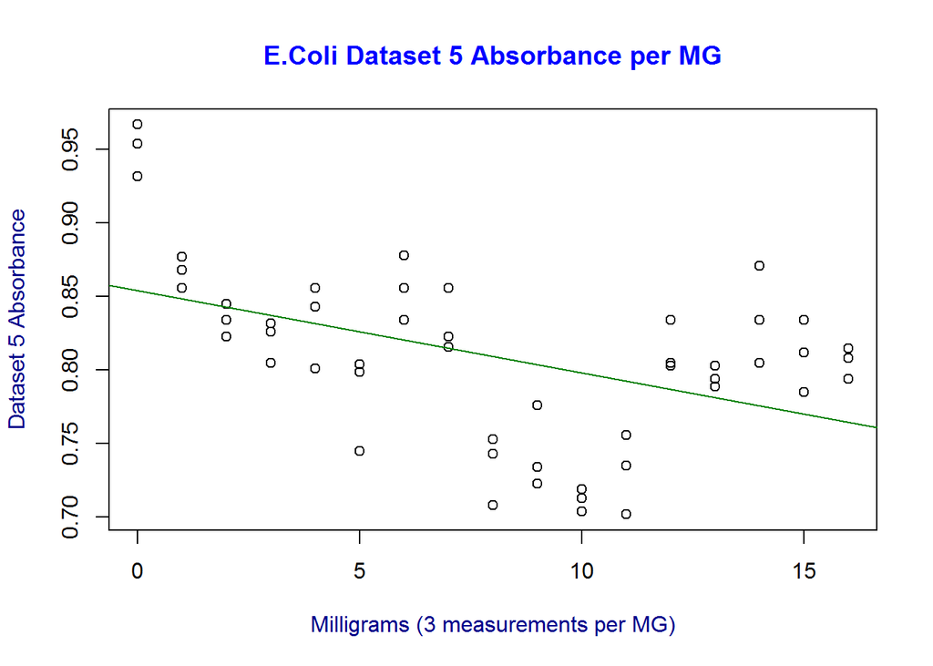

```r
plot(disc.vs.abs.e.Coli$disc_vs_abs_eColi, disc.vs.abs.e.Coli$Sample_1,
     main="E.Coli Dataset 5 Absorbance per MG",
     col.main="blue", xlab="Milligrams (3 measurements per MG)",
     ylab="Dataset 5 Absorbance",
     col.lab="darkblue")
abline(lm(disc.vs.abs.e.Coli$Sample_1~disc.vs.abs.e.Coli$disc_vs_abs_eColi),
       col="#008000")
```

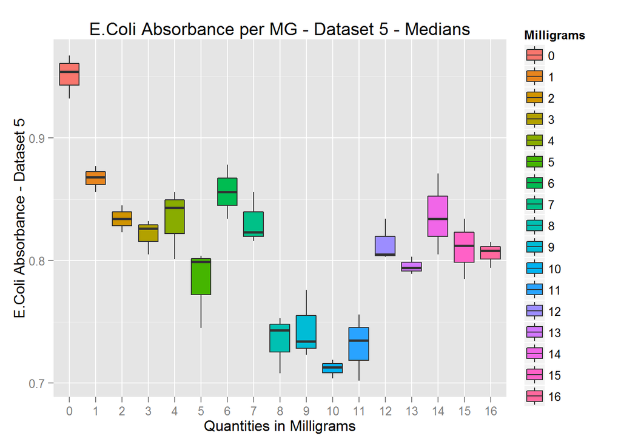

```r
ggplot(disc.vs.abs.e.Coli,
       aes(x=as.factor(disc.vs.abs.e.Coli$disc_vs_abs_eColi),
           y=disc.vs.abs.e.Coli$Sample_1)) +
geom_boxplot(aes(fill=as.factor(disc.vs.abs.e.Coli$disc_vs_abs_eColi))) +
ggtitle("E.Coli Absorbance per MG - Dataset 5 - Medians") +
xlab("Quantities in Milligrams") + ylab("E.Coli Absorbance - Dataset 5") +
labs(fill="Milligrams")
```

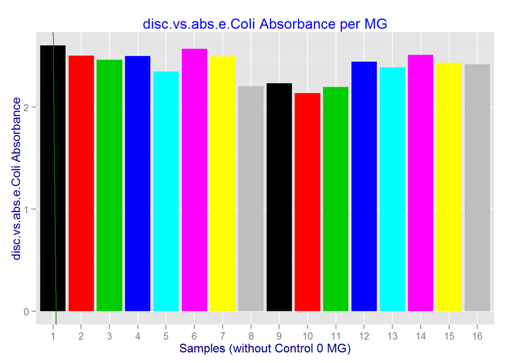

```r
rLine <- coef(lm(disc.vs.abs.e.Coli$disc_vs_abs_eColi[4:51]~
                   disc.vs.abs.e.Coli$Sample_1[4:51],
                 data=disc.vs.abs.e.Coli[4:51,]))
layout(matrix(1,1,1))
ggplot(disc.vs.abs.e.Coli[4:51,],
       aes(x=as.factor(disc.vs.abs.e.Coli$disc_vs_abs_eColi[4:51]),
                              y=disc.vs.abs.e.Coli$Sample_1[4:51])) +
  geom_bar(aes(), stat="identity",
           fill=as.factor(disc.vs.abs.e.Coli$disc_vs_abs_eColi[4:51])) +
  ggtitle("disc.vs.abs.e.Coli Absorbance per MG") +
  xlab("Samples (without Control 0 MG)") +
  ylab("disc.vs.abs.e.Coli Absorbance") +
  theme(plot.title=element_text(color="blue")) +
  theme(axis.title=element_text(color="darkblue")) +
  geom_abline(intercept=rLine[1], slope=rLine[2], col="#008000")
```

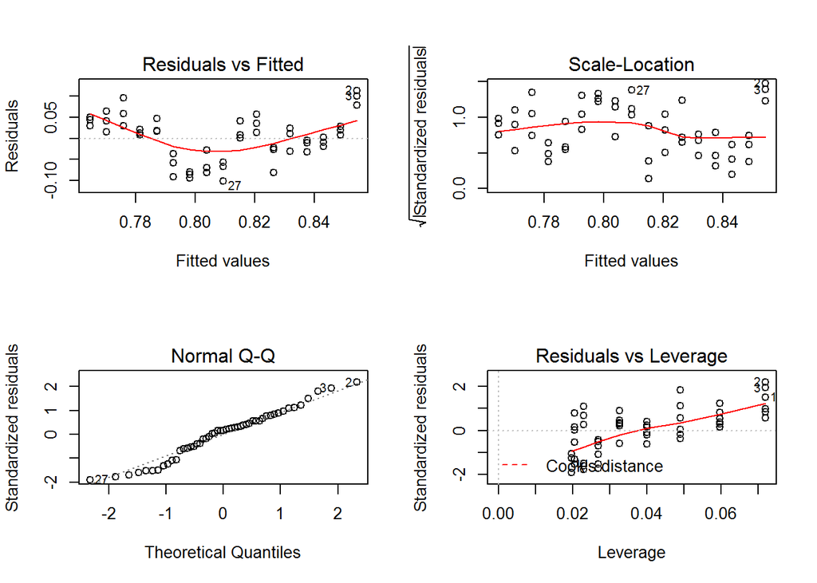

```r
fit <- lm(disc.vs.abs.e.Coli$Sample_1~disc.vs.abs.e.Coli$disc_vs_abs_eColi)
layout(matrix(c(1,2,3,4),2,2))
plot(fit)
```

### Dataset 5 - Linear Regression Plots

1. Residuals vs. Fitted - the shape of the plot shows a linear relationship in the sixteen samples of the disc.vs.abs.e.Coli data.
2. Normal Q-Q - shows the data points corresponding with the theoritical quantities. Thereby, demonstrating accuracy of the Linear Regression, and predictive ability of the data in Dataset 5 - disc.vs.abs.e.Coli.
3. Scale-Location - demonstrates homoscedasticity, or equal distribution of residuals along the range of predictors of Dataset 5 - disc.vs.abs.e.Coli.
4. Residuals vs Leverage - the Cook’s distance line is visible, within the plot. Data points 20 and 30 are identified as influential cases in Dataset 5 - disc.vs.abs.e.Coli.

```r
cor.test(as.numeric(disc.vs.abs.e.Coli$disc_vs_abs_eColi),
         disc.vs.abs.e.Coli$Sample_1, method="spearman")
```

```
##
##  Spearman's rank correlation rho
##
## data:  as.numeric(disc.vs.abs.e.Coli$disc_vs_abs_eColi) and disc.vs.abs.e.Coli$Sample_1
## S = 32327, p-value = 0.0006278
## alternative hypothesis: true rho is not equal to 0
## sample estimates:
##        rho
## -0.4627737
```

### Dataset 5 - Spearman’s Rank Correlation

The test statistic equals 32327, therefore Dataset 5 - disc.vs.abs.e.Coli demonstrates high reliability. The P-Value is lower than 0.05, therefore showing accurate predictor to response characteristics. The Spearman’s Rank, or rho, never equals 0, and the Null Hypothesis isn’t supported.

```r
t.test(as.numeric(disc.vs.abs.e.Coli$disc_vs_abs_eColi),
         disc.vs.abs.e.Coli$Sample_1)
```

```
##
##  Welch Two Sample t-test
##
## data:  as.numeric(disc.vs.abs.e.Coli$disc_vs_abs_eColi) and disc.vs.abs.e.Coli$Sample_1
## t = 10.378, df = 50.015, p-value = 4.531e-14
## alternative hypothesis: true difference in means is not equal to 0
## 95 percent confidence interval:
##  5.798887 8.582211
## sample estimates:
## mean of x mean of y
##  8.000000  0.809451
```

### Dataset 5 - T-Test

The Null Hypothesis is rejected, because the 95% confidence interval, of Dataset 5 - disc.vs.abs.e.Coli, has a median above 1.5. The Alternate Hypothesis results are not equal to zero, therefore not supported by the data.

# Dataset 6 - Data Input

```r
disc_SA <- read.xlsx("disc_SA.xlsx", 1)
```

# Dataset 6 - Graphs, Linear Regression, Correlation, and T-Tests

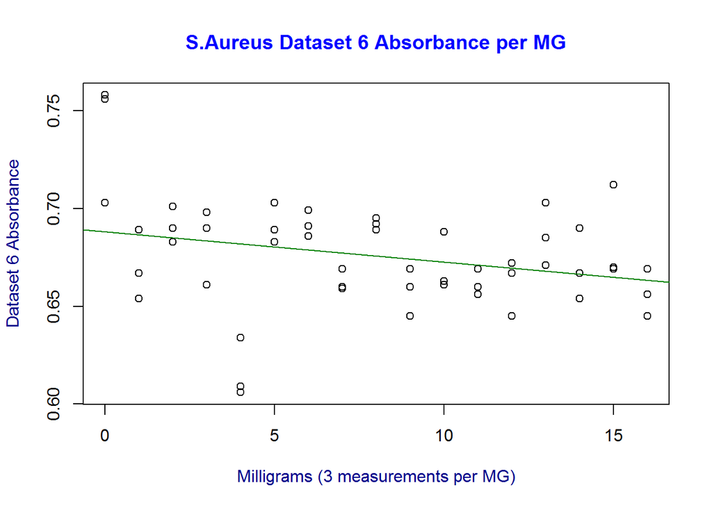

```r
plot(disc.vs.abs.S.Aureus$disc_vs_abs_S_Aureus,
     disc.vs.abs.S.Aureus$Sample_1,
     main="S.Aureus Dataset 6 Absorbance per MG",
     col.main="blue", xlab="Milligrams (3 measurements per MG)",
     ylab="Dataset 6 Absorbance",
     col.lab="darkblue")
abline(lm(disc.vs.abs.S.Aureus$Sample_1~
            disc.vs.abs.S.Aureus$disc_vs_abs_S_Aureus), col="#008000")
```

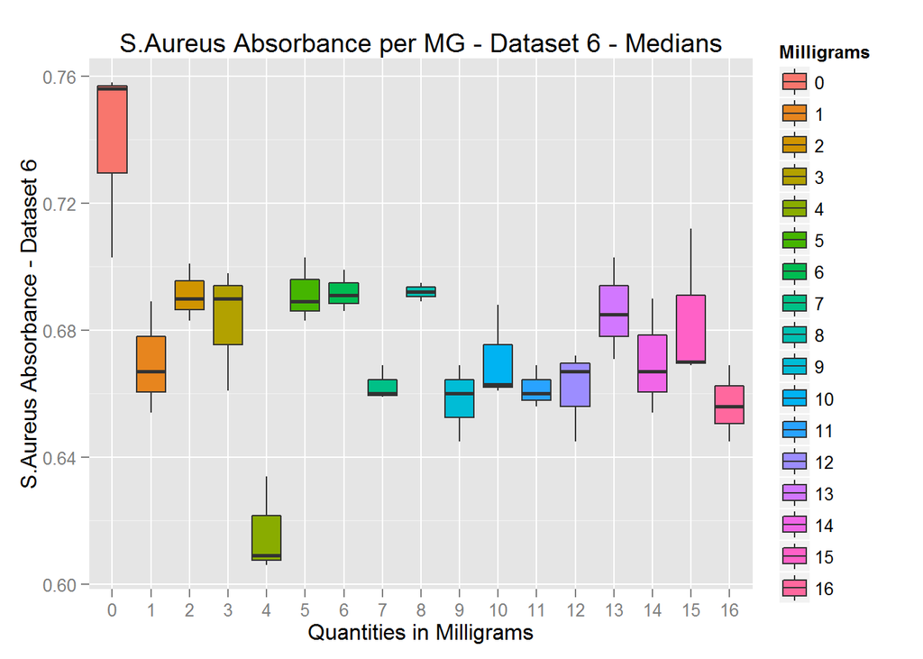

```r
ggplot(disc.vs.abs.S.Aureus,
       aes(x=as.factor(disc.vs.abs.S.Aureus$disc_vs_abs_S_Aureus),
           y=disc.vs.abs.S.Aureus$Sample_1)) +
geom_boxplot(aes(fill=as.factor(disc.vs.abs.S.Aureus$disc_vs_abs_S_Aureus))) +
ggtitle("S.Aureus Absorbance per MG - Dataset 6 - Medians") +
xlab("Quantities in Milligrams") + ylab("S.Aureus Absorbance - Dataset 6") +
labs(fill="Milligrams")
```

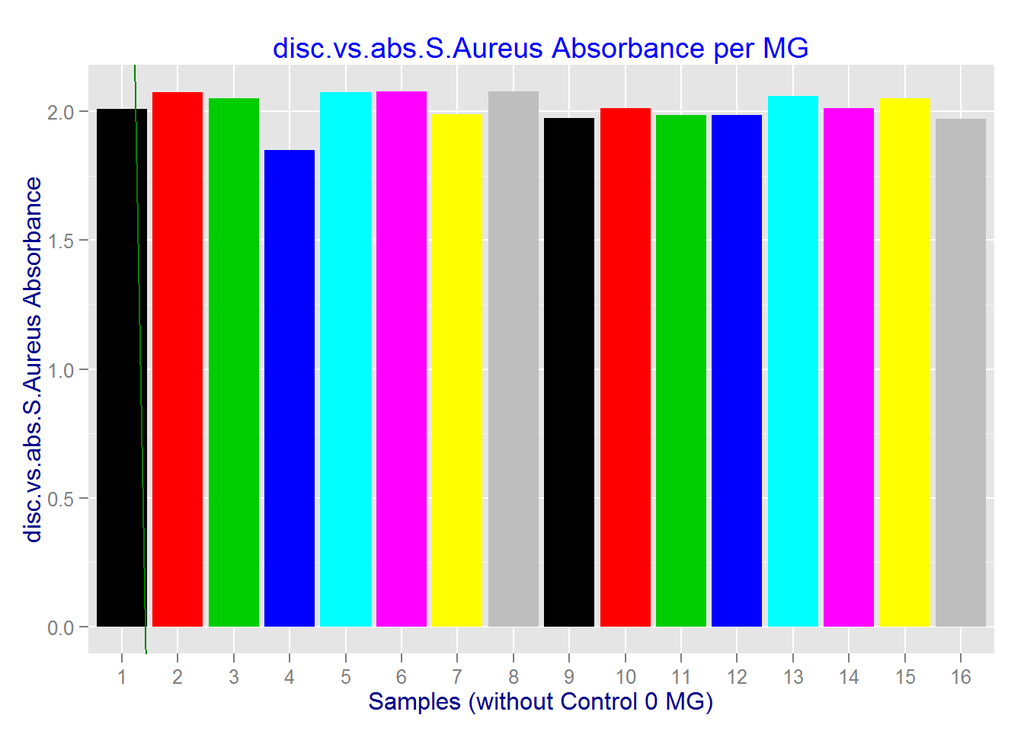

```r
rLine <- coef(lm(disc.vs.abs.S.Aureus$disc_vs_abs_S_Aureus[4:51]~
                   disc.vs.abs.S.Aureus$Sample_1[4:51],
                 data=disc.vs.abs.S.Aureus[4:51,]))
layout(matrix(1,1,1))
ggplot(disc.vs.abs.S.Aureus[4:51,],
       aes(x=as.factor(disc.vs.abs.S.Aureus$disc_vs_abs_S_Aureus[4:51]),
                              y=disc.vs.abs.S.Aureus$Sample_1[4:51])) +
  geom_bar(aes(), stat="identity",
           fill=as.factor(disc.vs.abs.S.Aureus$disc_vs_abs_S_Aureus[4:51])) +
  ggtitle("disc.vs.abs.S.Aureus Absorbance per MG") +
  xlab("Samples (without Control 0 MG)") +
  ylab("disc.vs.abs.S.Aureus Absorbance") +
  theme(plot.title=element_text(color="blue")) +
  theme(axis.title=element_text(color="darkblue")) +
  geom_abline(intercept=rLine[1], slope=rLine[2], col="#008000")
```

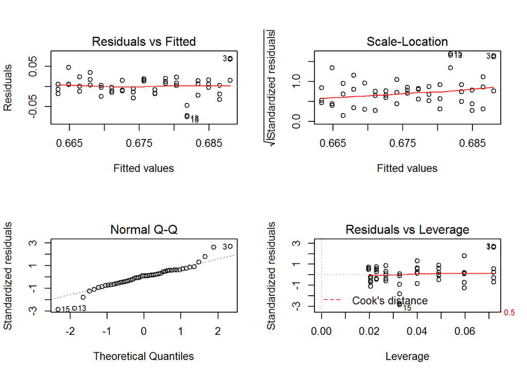

```r
fit <- lm(disc.vs.abs.S.Aureus$Sample_1~
            disc.vs.abs.S.Aureus$disc_vs_abs_S_Aureus)
layout(matrix(c(1,2,3,4),2,2))
plot(fit)
```

### Dataset 6 - Linear Regression Plots

1. Residuals vs. Fitted - there is a partially linear relationship in the sixteen sets of data points of the Dataset 6 - disc.vs.abs.S.Aureus data.
2. Normal Q-Q - shows the data points mostly corresponding with the theoritical quantities. Thereby, demonstrating accuracy of the Linear Regression, and predictive ability of the data in Dataset 6 - disc.vs.abs.S.Aureus data.
3. Scale-Location - Dataset 6 - disc.vs.abs.S.Aureus, demonstrates homoscedasticity, (equal distribution of residuals along the range of predictors).
4. Residuals vs Leverage - the Cook’s distance line is within the plot. Influential cases within Dataset 6 - disc.vs.abs.S.Aureus data are data points 15 and 30.

```r
cor.test(as.numeric(disc.vs.abs.S.Aureus$disc_vs_abs_S_Aureus),
         disc.vs.abs.S.Aureus$Sample_1, method="spearman")
```

```
##
##  Spearman's rank correlation rho
##
## data:  as.numeric(disc.vs.abs.S.Aureus$disc_vs_abs_S_Aureus) and disc.vs.abs.S.Aureus$Sample_1
## S = 28086, p-value = 0.05456
## alternative hypothesis: true rho is not equal to 0
## sample estimates:
##        rho
## -0.2708466
```

### Dataset 6 - Spearman’s Rank Correlation

The test statistic for Dataset 6 - disc.vs.abs.S.Aureus equals 28086, therefore a high accuracy of test results. The P-Value of 0.05456 is near the required P-Value of 0.05. The Spearman’s Rank, or rho, never equals 0, and the Null Hypothesis isn’t supported.

```r
t.test(as.numeric(disc.vs.abs.S.Aureus$disc_vs_abs_S_Aureus),
         disc.vs.abs.S.Aureus$Sample_1)
```

```
##
##  Welch Two Sample t-test
##
## data:  as.numeric(disc.vs.abs.S.Aureus$disc_vs_abs_S_Aureus) and disc.vs.abs.S.Aureus$Sample_1
## t = 10.572, df = 50.003, p-value = 2.394e-14
## alternative hypothesis: true difference in means is not equal to 0
## 95 percent confidence interval:
##  5.932723 8.715904
## sample estimates:
## mean of x mean of y
## 8.0000000 0.6756863
```

### Dataset 6 - T-Test

The Null Hypothesis is rejected, because the 95% confidence interval has a median above 1.5. The Alternate Hypothesis results are not equal to zero, therefore not supported by the data.

# Dataset 7 - Data Input

```r
fill_vs_ecoli <- read.xlsx("fill_vs_ecoli.xlsx", 1)
```

# Dataset 7 - Graphs, Linear Regression, Correlation, and T-Tests

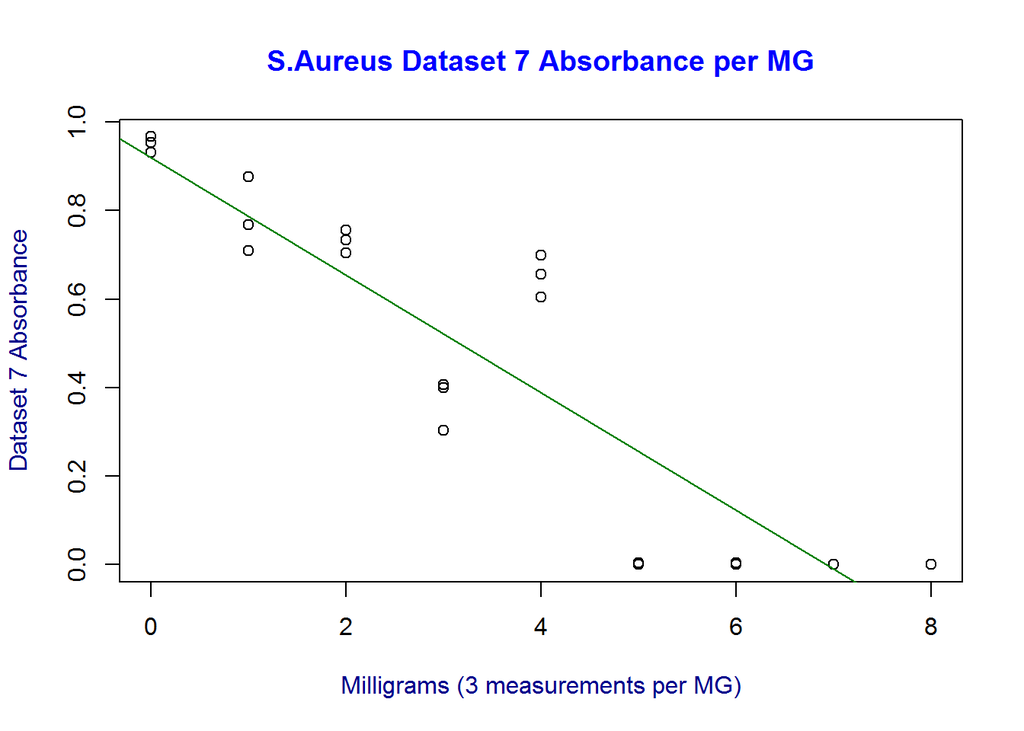

```r
plot(fill_vs_eColi$fill_vs_ABS_ecoli,
     fill_vs_eColi$Sample_1,
     main="S.Aureus Dataset 7 Absorbance per MG",
     col.main="blue", xlab="Milligrams (3 measurements per MG)",
     ylab="Dataset 7 Absorbance",
     col.lab="darkblue")
abline(lm(fill_vs_eColi$Sample_1~
            fill_vs_eColi$fill_vs_ABS_ecoli), col="#008000")
```

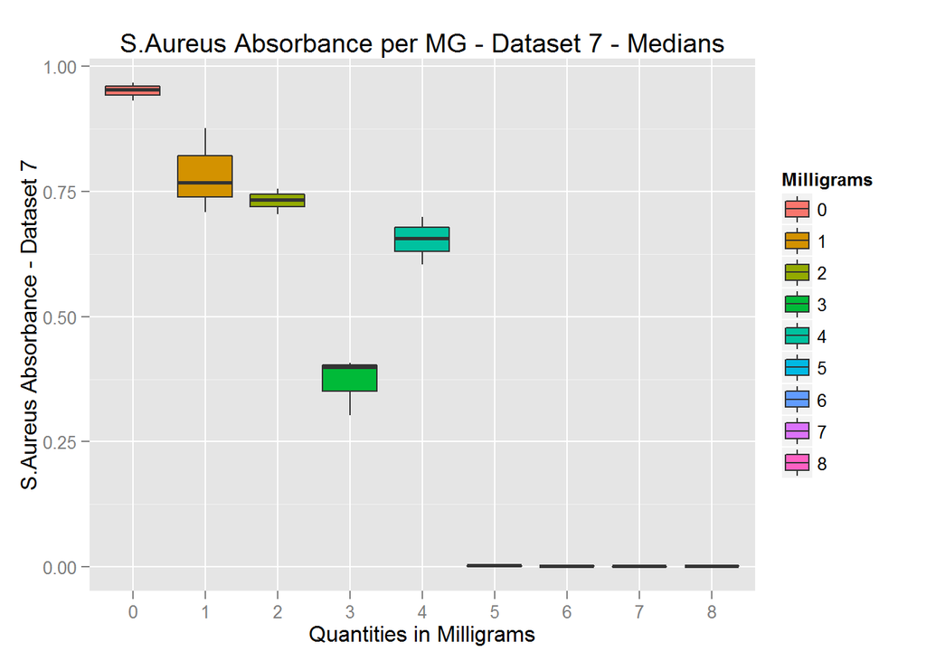

```r
ggplot(fill_vs_eColi,
       aes(x=as.factor(fill_vs_eColi$fill_vs_ABS_ecoli),
           y=fill_vs_eColi$Sample_1)) +
geom_boxplot(aes(fill=as.factor(fill_vs_eColi$fill_vs_ABS_ecoli))) +
ggtitle("S.Aureus Absorbance per MG - Dataset 7 - Medians") +
xlab("Quantities in Milligrams") + ylab("S.Aureus Absorbance - Dataset 7") +
labs(fill="Milligrams")
```

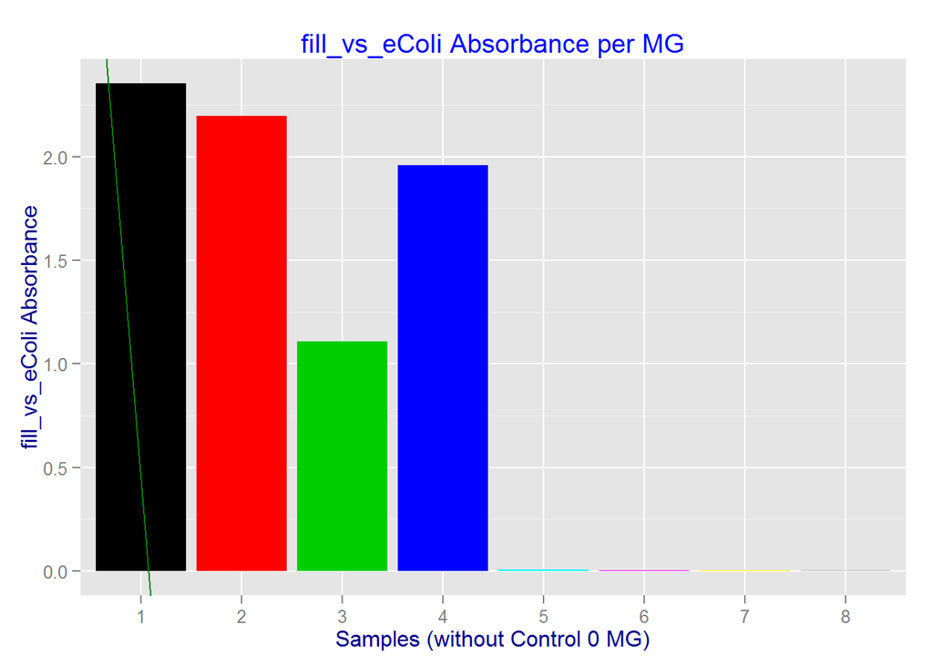

```r
rLine <- coef(lm(fill_vs_eColi$fill_vs_ABS_ecoli[4:27]~
                   fill_vs_eColi$Sample_1[4:27],
                 data=fill_vs_eColi[4:27,]))
layout(matrix(1,1,1))
ggplot(fill_vs_eColi[4:27,],
       aes(x=as.factor(fill_vs_eColi$fill_vs_ABS_ecoli[4:27]),
                              y=fill_vs_eColi$Sample_1[4:27])) +
  geom_bar(aes(), stat="identity",
           fill=as.factor(fill_vs_eColi$fill_vs_ABS_ecoli[4:27])) +
  ggtitle("fill_vs_eColi Absorbance per MG") +
  xlab("Samples (without Control 0 MG)") +
  ylab("fill_vs_eColi Absorbance") +
  theme(plot.title=element_text(color="blue")) +
  theme(axis.title=element_text(color="darkblue")) +
  geom_abline(intercept=rLine[1], slope=rLine[2], col="#008000")
```

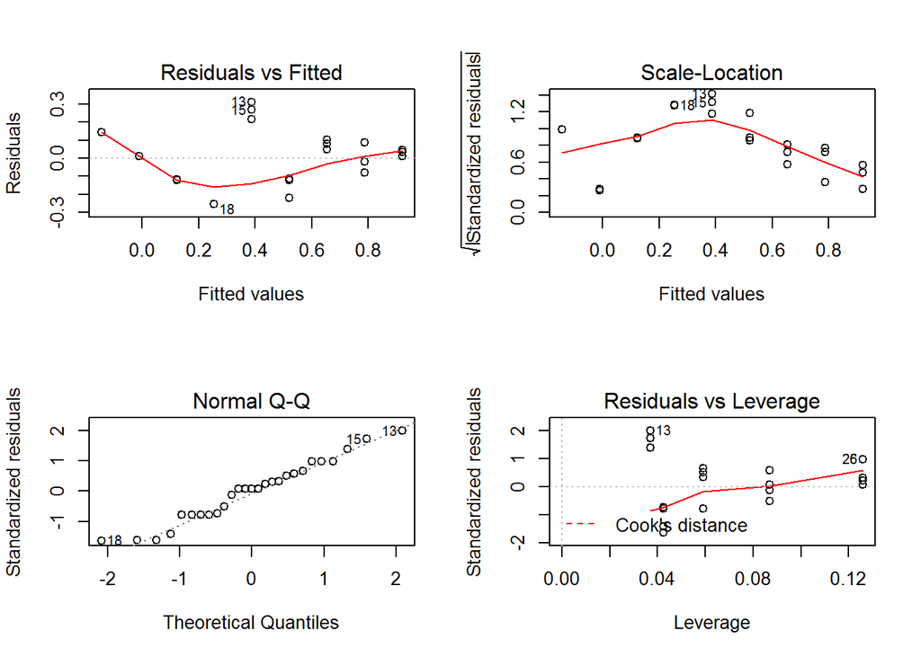

```r
fit <- lm(fill_vs_eColi$Sample_1~
            fill_vs_eColi$fill_vs_ABS_ecoli)
layout(matrix(c(1,2,3,4),2,2))
plot(fit)
```

### Dataset 7 - Linear Regression Plots

1. Residuals vs. Fitted - there is a linear relationship in the eight sets of three data points of Dataset 7 - fill_vs_eColi.
2. Normal Q-Q - shows the data points mostly corresponding with the theoritical quantities. Thereby, demonstrating accuracy of the Linear Regression of Dataset 7 - fill_vs_eColi.
3. Scale-Location - demonstrates homoscedasticity exists in Dataset 7 - fill_vs_eColi.
4. Residuals vs Leverage - the Cook’s distance line is within the plot. Therefore, influential cases exist within Dataset 7 - fill_vs_eColi. The specific influential data points are labeled, (data points 13 and 26).

```r
cor.test(as.numeric(fill_vs_eColi$fill_vs_ABS_ecoli),
         fill_vs_eColi$Sample_1, method="spearman")
```

```
##
##  Spearman's rank correlation rho
##
## data:  as.numeric(fill_vs_eColi$fill_vs_ABS_ecoli) and fill_vs_eColi$Sample_1
## S = 6367.6, p-value = 1.621e-13
## alternative hypothesis: true rho is not equal to 0
## sample estimates:
##        rho
## -0.9437148
```

### Dataset 7 - Spearman’s Rank Correlation

The test statistic equals 6367.6, therefore Dataset 7 - fill_vs_eColi demonstrate predictor reliability. The Spearman’s Rank, or rho, never equals 0, and the Null Hypothesis isn’t supported.

```r
t.test(as.numeric(fill_vs_eColi$fill_vs_ABS_ecoli),
         fill_vs_eColi$Sample_1)
```

```
##
##  Welch Two Sample t-test
##
## data:  as.numeric(fill_vs_eColi$fill_vs_ABS_ecoli) and fill_vs_eColi$Sample_1
## t = 7.058, df = 27.1, p-value = 1.346e-07
## alternative hypothesis: true difference in means is not equal to 0
## 95 percent confidence interval:
##  2.561852 4.661333
## sample estimates:
## mean of x mean of y
## 4.0000000 0.3884074
```

### Dataset 7 - T-Test

Dataset 7 - fill_vs_eColi test results do not conclusively predict the behavior of the response variables accurately, however the Null Hypothesis is rejected, because the 95% confidence interval has a median above 1.5. The Alternate Hypothesis results are not equal to zero, therefore the Alternate Hypothesis is not supported by the data.

# Dataset 8 - Data Input

```r
fil_vs_S_aureus2 <- read.xlsx("fil_vs_S_aureus2.xlsx", 1)
```

# Dataset 8 - Graphs, Linear Regression, Correlation, and T-Tests

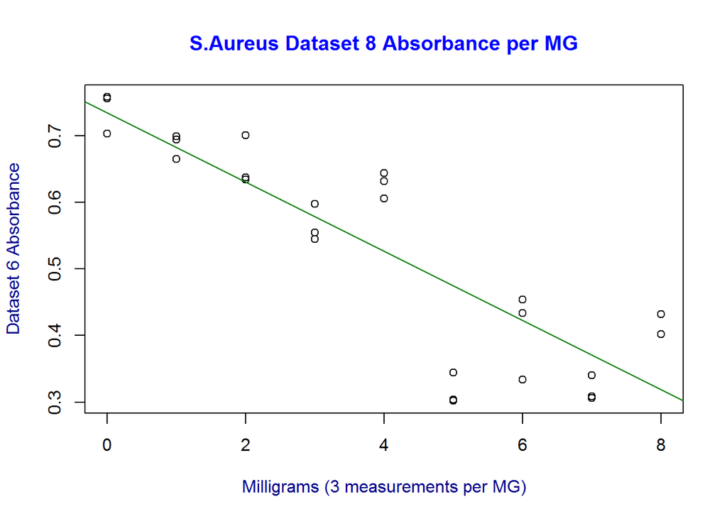

```r
plot(fil_vs_S_Aureus2$fil_vs_ABS_S_Aureus,
     fil_vs_S_Aureus2$Sample_1,
     main="S.Aureus Dataset 8 Absorbance per MG",
     col.main="blue", xlab="Milligrams (3 measurements per MG)",
     ylab="Dataset 6 Absorbance",
     col.lab="darkblue")
abline(lm(fil_vs_S_Aureus2$Sample_1~
            fil_vs_S_Aureus2$fil_vs_ABS_S_Aureus), col="#008000")
```

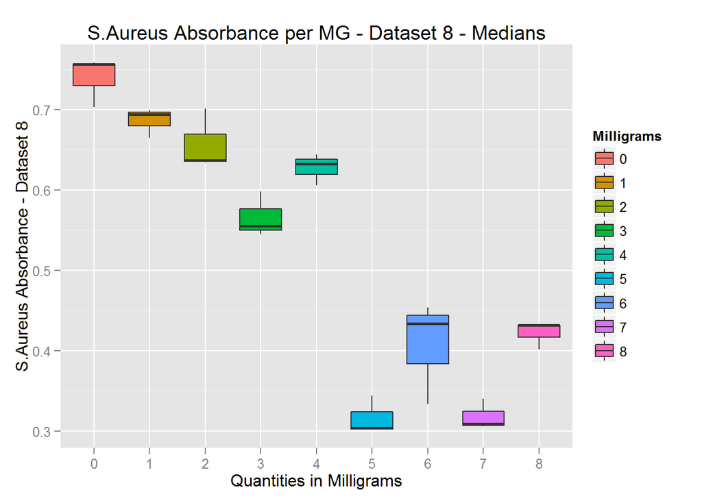

```r
ggplot(fil_vs_S_Aureus2,
       aes(x=as.factor(fil_vs_S_Aureus2$fil_vs_ABS_S_Aureus),
           y=fil_vs_S_Aureus2$Sample_1)) +
geom_boxplot(aes(fill=as.factor(fil_vs_S_Aureus2$fil_vs_ABS_S_Aureus))) +
ggtitle("S.Aureus Absorbance per MG - Dataset 8 - Medians") +
xlab("Quantities in Milligrams") + ylab("S.Aureus Absorbance - Dataset 8") +
labs(fill="Milligrams")
```

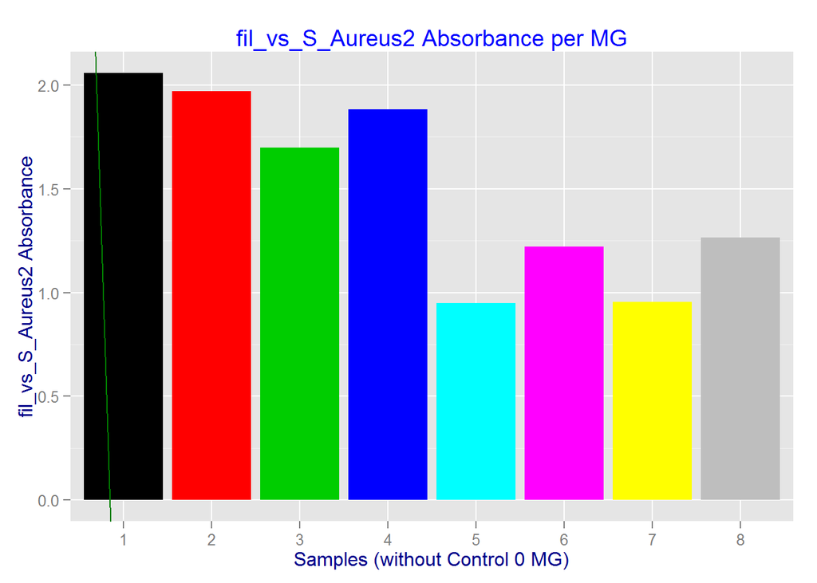

```r
rLine <- coef(lm(fil_vs_S_Aureus2$fil_vs_ABS_S_Aureus[4:27]~
                   fil_vs_S_Aureus2$Sample_1[4:27],
                 data=fil_vs_S_Aureus2[4:27,]))
layout(matrix(1,1,1))
ggplot(fil_vs_S_Aureus2[4:27,],
       aes(x=as.factor(fil_vs_S_Aureus2$fil_vs_ABS_S_Aureus[4:27]),
                              y=fil_vs_S_Aureus2$Sample_1[4:27])) +
  geom_bar(aes(), stat="identity",
           fill=as.factor(fil_vs_S_Aureus2$fil_vs_ABS_S_Aureus[4:27])) +
  ggtitle("fil_vs_S_Aureus2 Absorbance per MG") +
  xlab("Samples (without Control 0 MG)") +
  ylab("fil_vs_S_Aureus2 Absorbance") +
  theme(plot.title=element_text(color="blue")) +
  theme(axis.title=element_text(color="darkblue")) +
  geom_abline(intercept=rLine[1], slope=rLine[2], col="#008000")
```

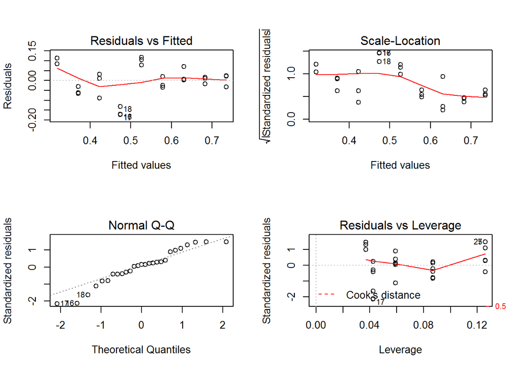

```r
fit <- lm(fil_vs_S_Aureus2$Sample_1~
            fil_vs_S_Aureus2$fil_vs_ABS_S_Aureus)
layout(matrix(c(1,2,3,4),2,2))
plot(fit)
```

### Dataset 8 - Linear Regression Plots

```r
cor.test(as.numeric(fil_vs_S_Aureus2$fil_vs_ABS_S_Aureus),
         fil_vs_S_Aureus2$Sample_1, method="spearman")
```

```
##
##  Spearman's rank correlation rho
##
## data:  as.numeric(fil_vs_S_Aureus2$fil_vs_ABS_S_Aureus) and fil_vs_S_Aureus2$Sample_1
## S = 6057.7, p-value = 2.154e-08
## alternative hypothesis: true rho is not equal to 0
## sample estimates:
##        rho
## -0.8491297
```

### Dataset 8 - Spearman’s Rank Correlation

The test statistic equals 6057.7, therefore Dataset 8 - fil_vs_S_Aureus2 demonstrates predictor reliability. The Spearman’s Rank, or rho, is not equal to zero, and the Null Hypothesis isn’t supported.

```r
t.test(as.numeric(fil_vs_S_Aureus2$fil_vs_ABS_S_Aureus),
         fil_vs_S_Aureus2$Sample_1)
```

```
##
##  Welch Two Sample t-test
##
## data:  as.numeric(fil_vs_S_Aureus2$fil_vs_ABS_S_Aureus) and fil_vs_S_Aureus2$Sample_1
## t = 6.8469, df = 26.189, p-value = 2.766e-07
## alternative hypothesis: true difference in means is not equal to 0
## 95 percent confidence interval:
##  2.430952 4.515715
## sample estimates:
## mean of x mean of y
## 4.0000000 0.5266667
```

### Dataset 8 - T-Test

The Null Hypothesis is rejected, for Dataset 8 - fil_vs_S_Aureus2, because the 95% confidence interval has a median above 1.5. The Alternate Hypothesis results are not equal to zero, therefore not supported by the data.